# Sprawozdanie 2

Łukasz Maczek, Marta Kreis

2025-10-25

# Potrzebne biblioteki

```r
library(stats)
library(e1071)
library(dplyr)
library(mice)
library(caret)
library(pROC)
library(tidyr)
library(ggplot2)
library(knitr)
library(kableExtra)
```

# Wczytanie i obróbka danych

```r
dane_stroke = read.csv2("stroke.csv", dec = ".")
head(dane_stroke)
```

```
##   gender age hypertension heart_disease ever_married     work_type
## 1   Male  67            0             1          Yes       Private
## 2 Female  61            0             0          Yes Self-employed
## 3   Male  80            0             1          Yes       Private
## 4 Female  49            0             0          Yes       Private
## 5 Female  79            1             0          Yes Self-employed
## 6   Male  81            0             0          Yes       Private
##   Residence_type avg_glucose_level  bmi  smoking_status stroke
## 1          Urban            228.69 36.6 formerly smoked      1
## 2          Rural            202.21   NA    never smoked      1
## 3          Rural            105.92 32.5    never smoked      1
## 4          Urban            171.23 34.4          smokes      1
## 5          Rural            174.12 24.0    never smoked      1
## 6          Urban            186.21 29.0 formerly smoked      1
```

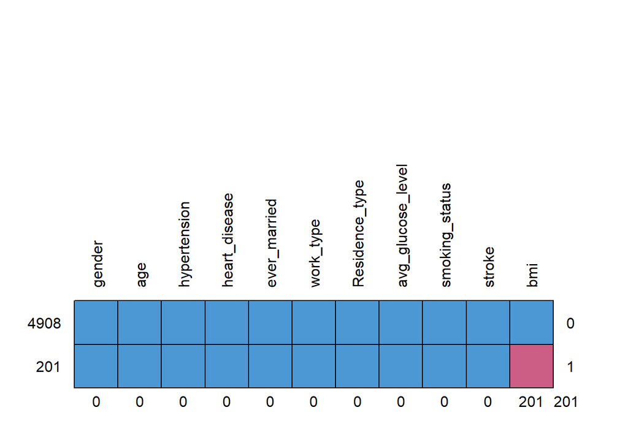

```
##      gender age hypertension heart_disease ever_married work_type
## 4908      1   1            1             1            1         1
## 201       1   1            1             1            1         1
##           0   0            0             0            0         0
##      Residence_type avg_glucose_level smoking_status stroke bmi
## 4908              1                 1              1      1   1   0
## 201               1                 1              1      1   0   1
##                   0                 0              0      0 201 201
```

```r
md.pattern(dane_stroke, rotate.names = TRUE)
```

```r
dane_stroke = na.omit(dane_stroke)
md.pattern(dane_stroke, rotate.names = TRUE)
```

```
##  /\     /\
## {  `---'  }
## {  O   O  }
## ==>  V <==  No need for mice. This data set is completely observed.
##  \  \|/  /
##   `-----'
```

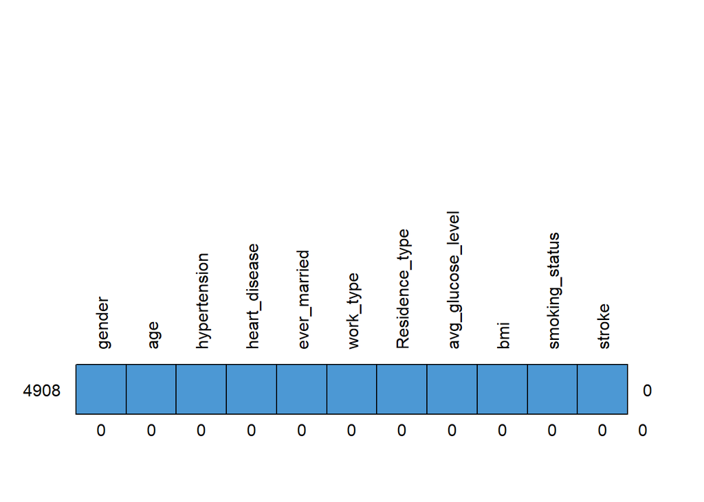

```
##      gender age hypertension heart_disease ever_married work_type
## 4908      1   1            1             1            1         1
##           0   0            0             0            0         0
##      Residence_type avg_glucose_level bmi smoking_status stroke
## 4908              1                 1   1              1      1 0
##                   0                 0   0              0      0 0
```

```r
dane_stroke$gender = ifelse(dane_stroke$gender=="Male", 1, 0) # Male to 1
dane_stroke$ever_married = ifelse(dane_stroke$ever_married=="Yes", 1, 0)
dane_stroke$Residence_type = ifelse(dane_stroke$Residence_type=="Urban", 1, 0) #Urban to 1

dane_stroke$work_type = as.factor(dane_stroke$work_type)
dane_stroke$smoking_status = as.factor(dane_stroke$smoking_status)
dane_stroke$gender = as.factor(dane_stroke$gender)
dane_stroke$hypertension = as.factor(dane_stroke$hypertension)
dane_stroke$heart_disease = as.factor(dane_stroke$heart_disease)
dane_stroke$ever_married = as.factor(dane_stroke$ever_married)
dane_stroke$Residence_type = as.factor(dane_stroke$Residence_type)
dane_stroke$stroke = as.factor(dane_stroke$stroke)
```

## Balansowanie zbioru

```r
stroke_0 = dane_stroke[dane_stroke$stroke == 0, ]
stroke_1 = dane_stroke[dane_stroke$stroke == 1, ]

set.seed(123)
stroke_0_sample = stroke_0[sample(1:nrow(stroke_0), nrow(stroke_1)), ]

#cały zbiór zbalansowany
dane_stroke_final = rbind(stroke_0_sample, stroke_1)
```

## Sprawdzenie na wykresie pudełkowym wartości odstających

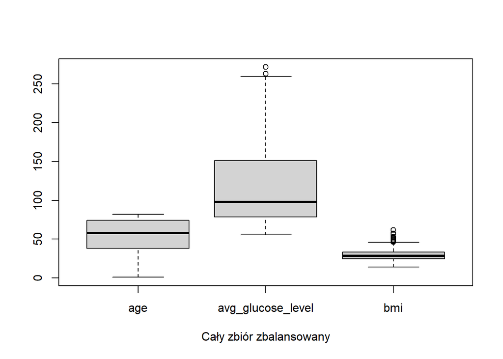

```r
boxplot(dane_stroke_final[c("age", "avg_glucose_level", "bmi")], xlab="Cały zbiór zbalansowany")
```

## Utworzenie zbioru bez wartości odstających

```r
num_cols <- c("age", "avg_glucose_level", "bmi")

remove_outliers_iqr <- function(data, column) {
  Q1 <- quantile(data[[column]], 0.25, na.rm = TRUE)
  Q3 <- quantile(data[[column]], 0.75, na.rm = TRUE)
  IQR_value <- Q3 - Q1

  lower_bound <- Q1 - 1.5 * IQR_value
  upper_bound <- Q3 + 1.5 * IQR_value

  before <- nrow(data)
  data_clean <- data %>%
    filter(.data[[column]] >= lower_bound & .data[[column]] <= upper_bound)
  after <- nrow(data_clean)

  cat(column, ": usunięto", before - after, "obserwacji\n")

  return(data_clean)
}

dane_stroke_final2 <- dane_stroke_final
for (col in num_cols) {
  dane_stroke_final2 <- remove_outliers_iqr(dane_stroke_final2, col)
}
```

```
## age : usunięto 0 obserwacji
## avg_glucose_level : usunięto 3 obserwacji
## bmi : usunięto 13 obserwacji
```

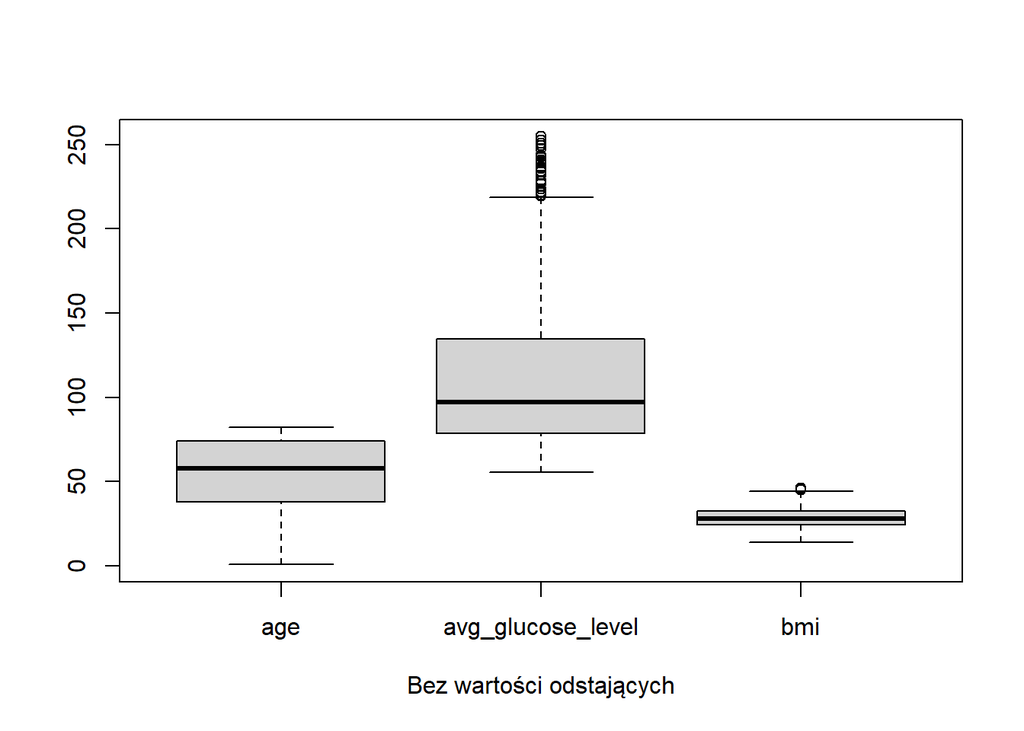

```r
boxplot(dane_stroke_final2[c("age", "avg_glucose_level", "bmi")], xlab="Bez wartości odstających")
```

## Podział na zbiór uczący i testowy

```r
set.seed(123)
index = sample(length(dane_stroke_final$gender), 85) #około 20% wszystkich obserwacji (418)
testowy = dane_stroke_final[index,]
uczacy = dane_stroke_final[-index,]

summary(uczacy) #Brak wartości dla work_type Never_worked
```

```
##  gender       age        hypertension heart_disease ever_married
##  0:212   Min.   : 0.80   0:270        0:300         0: 78
##  1:121   1st Qu.:39.00   1: 63        1: 33         1:255
##          Median :58.00
##          Mean   :54.12
##          3rd Qu.:74.00
##          Max.   :82.00
##          work_type   Residence_type avg_glucose_level      bmi
##  children     : 23   0:155          Min.   : 55.35    Min.   :14.10
##  Govt_job     : 50   1:178          1st Qu.: 78.48    1st Qu.:24.60
##  Never_worked :  0                  Median : 97.43    Median :28.20
##  Private      :204                  Mean   :117.26    Mean   :29.36
##  Self-employed: 56                  3rd Qu.:131.41    3rd Qu.:32.90
##                                     Max.   :271.74    Max.   :61.60
##          smoking_status stroke
##  formerly smoked: 72    0:170
##  never smoked   :143    1:163
##  smokes         : 49
##  Unknown        : 69
##
##
```

```r
summary(testowy) #Brak wartości dla work_type Never_worked
```

```
##  gender      age        hypertension heart_disease ever_married
##  0:48   Min.   : 1.00   0:68         0:73          0:24
##  1:37   1st Qu.:37.00   1:17         1:12          1:61
##         Median :58.00
##         Mean   :53.99
##         3rd Qu.:74.00
##         Max.   :82.00
##          work_type  Residence_type avg_glucose_level      bmi
##  children     : 9   0:41           Min.   : 56.11    Min.   :15.10
##  Govt_job     : 9   1:44           1st Qu.: 79.79    1st Qu.:24.20
##  Never_worked : 0                  Median :105.92    Median :29.10
##  Private      :49                  Mean   :131.79    Mean   :29.36
##  Self-employed:18                  3rd Qu.:191.82    3rd Qu.:33.70
##                                    Max.   :254.60    Max.   :47.50
##          smoking_status stroke
##  formerly smoked:15     0:39
##  never smoked   :33     1:46
##  smokes         :15
##  Unknown        :22
##
##
```

```r
#Podział na zbiór uczący i testowy bez wartości odstających
set.seed(123)
index2 = sample(length(dane_stroke_final2$gender), 77) #około 20% wszystkich obserwacji (383)
testowy2 = dane_stroke_final2[index,]
uczacy2 = dane_stroke_final2[-index,]
```

# Zadanie 1

## Regresja logistyczna na modelu na całym zbalansowanym zbiorze

```r
#model na całym zbalansowanym zbiorze
glm_model = glm(stroke ~ ., data = uczacy, family = "binomial")
summary(glm_model)
```

```
##
## Call:
## glm(formula = stroke ~ ., family = "binomial", data = uczacy)
##
## Coefficients:
##                              Estimate Std. Error z value Pr(>|z|)
## (Intercept)                -18.274763 812.648196  -0.022    0.982
## gender1                      0.280756   0.313469   0.896    0.370
## age                          0.077408   0.011109   6.968 3.22e-12 ***
## hypertension1                0.582379   0.380788   1.529    0.126
## heart_disease1               0.695098   0.598970   1.160    0.246
## ever_married1               -0.185504   0.486705  -0.381    0.703
## work_typeGovt_job           13.124024 812.648314   0.016    0.987
## work_typePrivate            13.171296 812.648261   0.016    0.987
## work_typeSelf-employed      13.447687 812.648361   0.017    0.987
## Residence_type1             -0.084998   0.292343  -0.291    0.771
## avg_glucose_level            0.003173   0.002981   1.064    0.287
## bmi                          0.010370   0.021018   0.493    0.622
## smoking_statusnever smoked  -0.265956   0.368073  -0.723    0.470
## smoking_statussmokes         0.453026   0.483615   0.937    0.349
## smoking_statusUnknown       -0.417566   0.480378  -0.869    0.385
## ---
## Signif. codes:  0 '***' 0.001 '**' 0.01 '*' 0.05 '.' 0.1 ' ' 1
##
## (Dispersion parameter for binomial family taken to be 1)
##
##     Null deviance: 461.49  on 332  degrees of freedom
## Residual deviance: 295.45  on 318  degrees of freedom
## AIC: 325.45
##
## Number of Fisher Scoring iterations: 16
```

```r
exp(coef(glm_model))
```

```
##                (Intercept)                    gender1
##               1.157102e-08               1.324130e+00
##                        age              hypertension1
##               1.080483e+00               1.790293e+00
##             heart_disease1              ever_married1
##               2.003906e+00               8.306857e-01
##          work_typeGovt_job           work_typePrivate
##               5.008310e+05               5.250749e+05
##     work_typeSelf-employed            Residence_type1
##               6.922391e+05               9.185144e-01
##          avg_glucose_level                        bmi
##               1.003178e+00               1.010424e+00
## smoking_statusnever smoked       smoking_statussmokes
##               7.664730e-01               1.573065e+00
##      smoking_statusUnknown
##               6.586479e-01
```

```r
#Predykcja na zbiorze uczącym
pred_uczacy = predict(glm_model, newdata = uczacy, type = "response")
prog_odciecia = 0.5
klasy_uczacy = ifelse(pred_uczacy >= prog_odciecia, 1, 0)
confusionMatrix(factor(klasy_uczacy), factor(uczacy$stroke), positive = "1")
```

```
## Confusion Matrix and Statistics
##
##           Reference
## Prediction   0   1
##          0 130  33
##          1  40 130
##
##                Accuracy : 0.7808
##                  95% CI : (0.7324, 0.824)
##     No Information Rate : 0.5105
##     P-Value [Acc > NIR] : <2e-16
##
##                   Kappa : 0.5618
##
##  Mcnemar's Test P-Value : 0.4825
##
##             Sensitivity : 0.7975
##             Specificity : 0.7647
##          Pos Pred Value : 0.7647
##          Neg Pred Value : 0.7975
##              Prevalence : 0.4895
##          Detection Rate : 0.3904
##    Detection Prevalence : 0.5105
##       Balanced Accuracy : 0.7811
##
##        'Positive' Class : 1
##
```

```r
roc_obj_u <- roc(uczacy$stroke, pred_uczacy)
auc(roc_obj_u)
```

```
## Area under the curve: 0.868
```

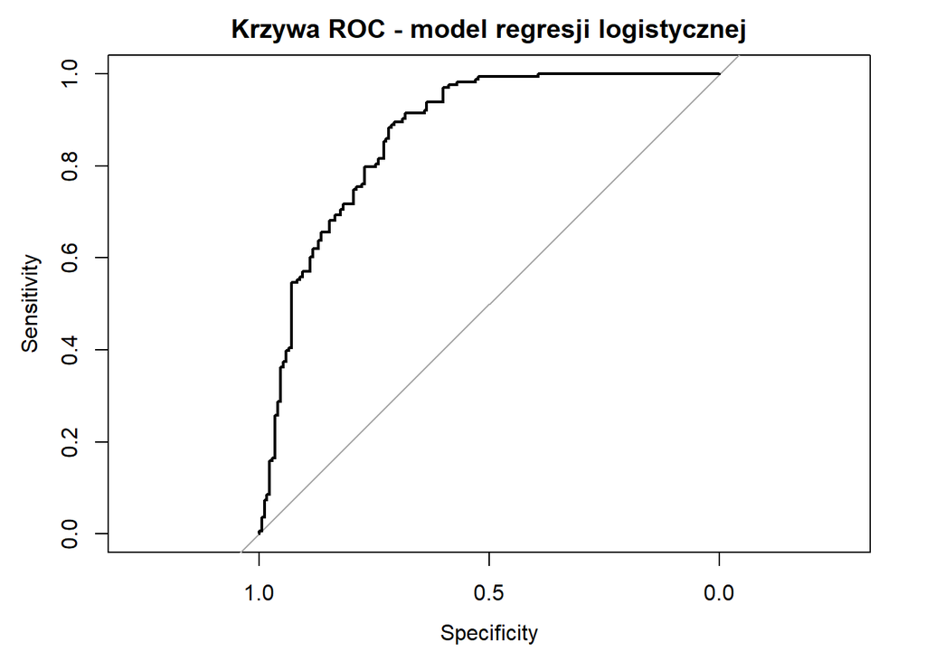

```r
plot(roc_obj_u, main = "Krzywa ROC - model regresji logistycznej")
```

```r
#Predykcja na zbiorze testowym
pred_testowy <- predict(glm_model, newdata = testowy, type = "response")
klasy_testowy <- ifelse(pred_testowy >= prog_odciecia, 1, 0)
confusionMatrix(factor(klasy_testowy), factor(testowy$stroke), positive = "1")
```

```
## Confusion Matrix and Statistics
##
##           Reference
## Prediction  0  1
##          0 29  8
##          1 10 38
##
##                Accuracy : 0.7882
##                  95% CI : (0.6861, 0.8694)
##     No Information Rate : 0.5412
##     P-Value [Acc > NIR] : 1.913e-06
##
##                   Kappa : 0.5719
##
##  Mcnemar's Test P-Value : 0.8137
##
##             Sensitivity : 0.8261
##             Specificity : 0.7436
##          Pos Pred Value : 0.7917
##          Neg Pred Value : 0.7838
##              Prevalence : 0.5412
##          Detection Rate : 0.4471
##    Detection Prevalence : 0.5647
##       Balanced Accuracy : 0.7848
##
##        'Positive' Class : 1
##
```

```r
roc_obj_t <- roc(testowy$stroke, pred_testowy)
auc(roc_obj_t)
```

```
## Area under the curve: 0.8501
```

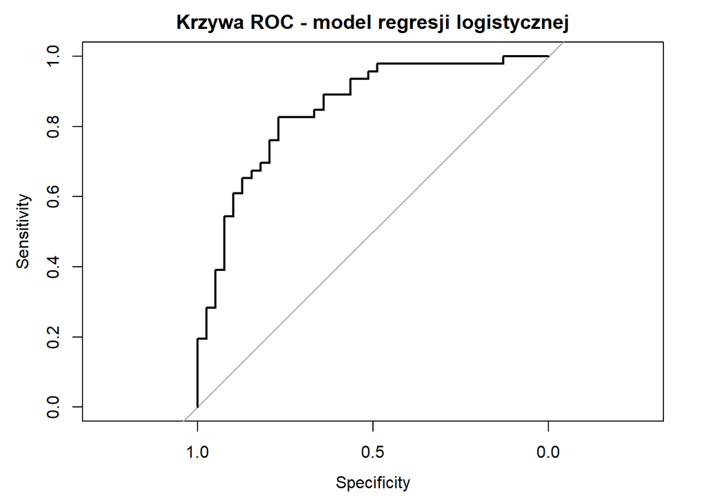

```r
plot(roc_obj_t, main = "Krzywa ROC - model regresji logistycznej")
```

## Regresja logistyczna na zbalansowanym zbiorze bez wartości odstających

```r
#model bez wartości odstających
glm_model2 = glm(stroke ~ ., data = uczacy2, family = "binomial")
summary(glm_model2)
```

```
##
## Call:
## glm(formula = stroke ~ ., family = "binomial", data = uczacy2)
##
## Coefficients:
##                              Estimate Std. Error z value Pr(>|z|)
## (Intercept)                -19.632193 808.023703  -0.024   0.9806
## gender1                      0.244902   0.318132   0.770   0.4414
## age                          0.086328   0.011790   7.322 2.44e-13 ***
## hypertension1                0.536616   0.386843   1.387   0.1654
## heart_disease1               0.563801   0.604838   0.932   0.3513
## ever_married1               -0.265372   0.493544  -0.538   0.5908
## work_typeGovt_job           12.981170 808.023724   0.016   0.9872
## work_typePrivate            12.878559 808.023674   0.016   0.9873
## work_typeSelf-employed      12.933304 808.023789   0.016   0.9872
## Residence_type1             -0.180437   0.303540  -0.594   0.5522
## avg_glucose_level            0.001303   0.003107   0.419   0.6750
## bmi                          0.057933   0.028967   2.000   0.0455 *
## smoking_statusnever smoked  -0.166256   0.388084  -0.428   0.6684
## smoking_statussmokes         0.629058   0.497157   1.265   0.2058
## smoking_statusUnknown        0.168680   0.473653   0.356   0.7217
## ---
## Signif. codes:  0 '***' 0.001 '**' 0.01 '*' 0.05 '.' 0.1 ' ' 1
##
## (Dispersion parameter for binomial family taken to be 1)
##
##     Null deviance: 447.77  on 322  degrees of freedom
## Residual deviance: 279.07  on 308  degrees of freedom
## AIC: 309.07
##
## Number of Fisher Scoring iterations: 16
```

```r
exp(coef(glm_model2))
```

```
##                (Intercept)                    gender1
##               2.977468e-09               1.277496e+00
##                        age              hypertension1
##               1.090164e+00               1.710210e+00
##             heart_disease1              ever_married1
##               1.757339e+00               7.669210e-01
##          work_typeGovt_job           work_typePrivate
##               4.341607e+05               3.918204e+05
##     work_typeSelf-employed            Residence_type1
##               4.138686e+05               8.349049e-01
##          avg_glucose_level                        bmi
##               1.001303e+00               1.059644e+00
## smoking_statusnever smoked       smoking_statussmokes
##               8.468291e-01               1.875843e+00
##      smoking_statusUnknown
##               1.183742e+00
```

```r
#Predykcja na zbiorze uczącym v2
pred_uczacy2 = predict(glm_model2, newdata = uczacy2, type = "response")
prog_odciecia2 = 0.5
klasy_uczacy2 = ifelse(pred_uczacy2 >= prog_odciecia2, 1, 0)
head(klasy_uczacy2, 10)
```

```
##  1  2  3  5  6  8  9 10 11 12
##  0  0  0  0  1  1  0  1  0  1
```

```r
confusionMatrix(factor(klasy_uczacy2), factor(uczacy2$stroke), positive = "1")
```

```
## Confusion Matrix and Statistics
##
##           Reference
## Prediction   0   1
##          0 121  24
##          1  41 137
##
##                Accuracy : 0.7988
##                  95% CI : (0.7508, 0.8411)
##     No Information Rate : 0.5015
##     P-Value [Acc > NIR] : < 2e-16
##
##                   Kappa : 0.5977
##
##  Mcnemar's Test P-Value : 0.04719
##
##             Sensitivity : 0.8509
##             Specificity : 0.7469
##          Pos Pred Value : 0.7697
##          Neg Pred Value : 0.8345
##              Prevalence : 0.4985
##          Detection Rate : 0.4241
##    Detection Prevalence : 0.5511
##       Balanced Accuracy : 0.7989
##
##        'Positive' Class : 1
##
```

```r
roc_obj_u2 <- roc(uczacy2$stroke, pred_uczacy2)
auc(roc_obj_u2)
```

```
## Area under the curve: 0.8755
```

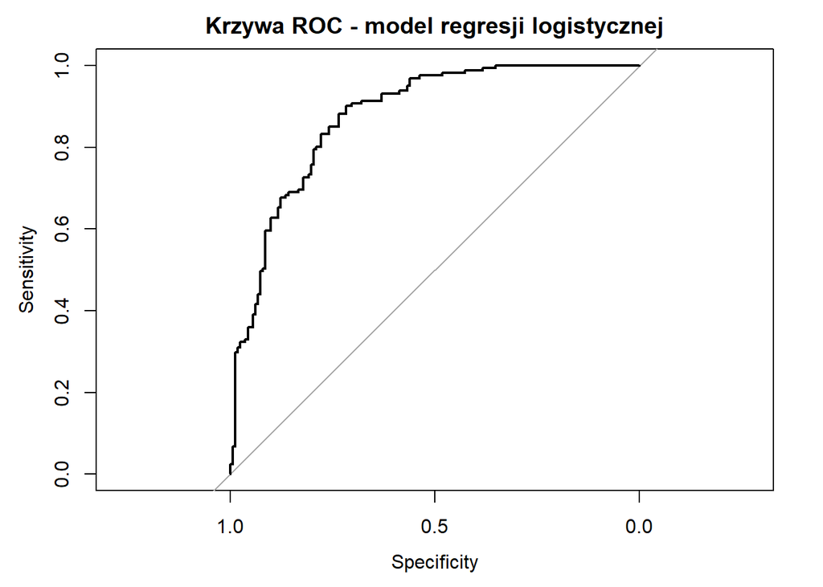

```r
plot(roc_obj_u2, main = "Krzywa ROC - model regresji logistycznej")
```

```r
#Predykcja na zbiorze testowym v2
pred_testowy2 <- predict(glm_model2, newdata = testowy2, type = "response")
klasy_testowy2 <- ifelse(pred_testowy2 >= prog_odciecia2, 1, 0)
confusionMatrix(factor(klasy_testowy2), factor(testowy2$stroke), positive = "1")
```

```
## Confusion Matrix and Statistics
##
##           Reference
## Prediction  0  1
##          0 29  8
##          1  9 33
##
##                Accuracy : 0.7848
##                  95% CI : (0.678, 0.8694)
##     No Information Rate : 0.519
##     P-Value [Acc > NIR] : 9.629e-07
##
##                   Kappa : 0.5686
##
##  Mcnemar's Test P-Value : 1
##
##             Sensitivity : 0.8049
##             Specificity : 0.7632
##          Pos Pred Value : 0.7857
##          Neg Pred Value : 0.7838
##              Prevalence : 0.5190
##          Detection Rate : 0.4177
##    Detection Prevalence : 0.5316
##       Balanced Accuracy : 0.7840
##
##        'Positive' Class : 1
##
```

```r
roc_obj_t2 <- roc(testowy2$stroke, pred_testowy2)
auc(roc_obj_t2)
```

```
## Area under the curve: 0.8678
```

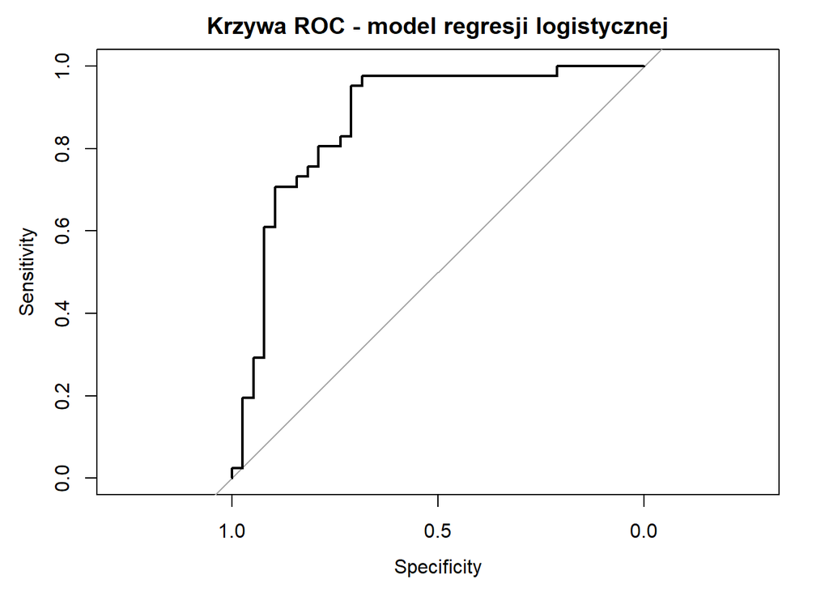

```r
plot(roc_obj_t2, main = "Krzywa ROC - model regresji logistycznej")
```

## Porównanie wpływu wartości odstających na regresję logistyczną

```r
cm_logit <- confusionMatrix(factor(klasy_testowy, levels = c(0,1)), factor(testowy$stroke, levels = c(0,1)), positive = "1")
roc_logit <- roc(testowy$stroke, pred_testowy)
cm_logit2 <- confusionMatrix(factor(klasy_testowy2, levels = c(0,1)), factor(testowy2$stroke, levels = c(0,1)), positive = "1")
roc_logit2 <- roc(testowy2$stroke, pred_testowy2)
df_porownanie = data.frame(
  Model = c("Logit", "Logit w/o outliers"),
  Accuracy = c(cm_logit$overall["Accuracy"], cm_logit2$overall["Accuracy"]),
  Sensitivity = c(cm_logit$byClass["Sensitivity"], cm_logit2$byClass["Sensitivity"]),
  Specificity = c(cm_logit$byClass["Specificity"], cm_logit2$byClass["Specificity"]),
  Precision = c(cm_logit$byClass["Precision"], cm_logit2$byClass["Precision"]),
  F1 = c(cm_logit$byClass["F1"], cm_logit2$byClass["F1"]),
  AUC = c(auc(roc_logit), auc(roc_logit2))
)
df_porownanie%>%
  kable("html", caption = "Porównanie logit z i bez wartości odstających") %>%
  kable_styling("striped", full_width = F, position = "center")
```

Porównanie logit z i bez wartości odstających

| Model | Accuracy | Sensitivity | Specificity | Precision | F1 | AUC |
| --- | --- | --- | --- | --- | --- | --- |
| Logit | 0.7882353 | 0.826087 | 0.7435897 | 0.7916667 | 0.8085106 | 0.8500557 |
| Logit w/o outliers | 0.7848101 | 0.804878 | 0.7631579 | 0.7857143 | 0.7951807 | 0.8677792 |

# Odpowiedzi na pytania z zadania 1

1. Założenia regresji logistycznej:
- niezależność obserwacji
- duża ilość obserwacji
- brak silnej współliniowości
- zmienna zależna musi być kategoryczna z 2 kategoriami
- zmienne niezależne mogą być kategoryczne
- liniowość logitu

2)Zmienne kategoryczne muszą być zakodowane jako zmienne zero-jedynkowe. U nas to zmienne- work_type, smoking_status, gender

3)Nie jest konieczna, bo regresja logistyczna nie jest oparta na odległościach w porównaniu do KNN, które robiliśmy na ostatnich labolatoriach.

4)Tak, mają wpływ, ponieważ regresja logistyczna używa estymacji metodą maksymalnego prawdopodobieństwa, która jest wrażliwa na obserwacje odstające. Sprawdziliśmy włpływ wartości odstających poprzez porównanie modelu podstawowego(glm_model) z modelem bez wartości odstających (glm_model2). Po porównaniu wnioskujemy: -Model bez wartości odstających ma poprawioną stabilność modelu oraz AUC

5)Wartości parametrów możemy odczytwyać bezpośrednio z postaci logitowej. Każdy współczynnik (β) oznacza wpływ zmiany danej zmiennej o 1 jednostkę na logit prawdopodobieństwa zajścia zdarzenia (u nas wystąpienia udaru).

**Wzór na regresję logistyczną**

Regresja logistyczna opisuje zależność między zmienną objaśnianą $y$ (0 lub 1) a zmiennymi objaśniającymi $x_1, x_2, \dots, x_k$.

W postaci logitowej:

$$\ln\left(\frac{p}{1 - p}\right) = \beta_0 + \beta_1 x_1 + \beta_2 x_2 +
\dots + \beta_k x_k$$
Interpretacja parametrów regresji logistycznej

1. Współczynnik β (beta) Pokazuje, jak zmiana jednostki danej zmiennej wpływa na logarytm szans wystąpienia zdarzenia (np. udaru).
   - β > 0 → zmiana zmiennej zwiększa ryzyko
   - β < 0 → zmiana zmniejsza ryzyko
2. Iloraz szans (OR = e^β)  
   Przekształcenie β na OR pozwala interpretować wynik w bardziej intuicyjny sposób:
   - OR > 1 → wzrost zmiennej zwiększa ryzyko zdarzenia
   - OR < 1 → wzrost zmiennej zmniejsza ryzyko zdarzenia
   - Przykład: OR = 1.05 dla wieku → każdy dodatkowy rok zwiększa szansę udaru o 5%
3. Przedział ufności (95% CI) Pokazuje zakres wartości, w którym z 95% pewnością mieści się prawdziwe OR.
   - Jeśli 95% CI nie zawiera 1 → zmienna istotnie wpływa na ryzyko
   - Przykład: CI = [1.02, 1.08] dla wieku → wiek ma istotny wpływ na ryzyko udaru

W postaci funkcji logistycznej:

$$p = \frac{1}{1 + e^{-(\beta_0 + \beta_1 x_1 + \beta_2 x_2 + \dots +
\beta_k x_k)}}$$
**Interpretacja wyników:** -Accuracy jest podobna w obu modelach (~0.78), czyli ogólna skuteczność nie zmieniła się znacząco po usunięciu wartości odstających.

-Sensitivity spada po usunięciu outlierów (0.826 → 0.805), czyli model częściej „przegapia” prawdziwe udary.

-Specificity rośnie (0.744 → 0.763), czyli model lepiej rozpoznaje osoby bez udaru.

-Precision i F1 lekko spadają, ale są wciąż na wysokim poziomie (~0.79).

-AUC rośnie (0.850 → 0.868), co sugeruje, że model bez outlierów lepiej rozróżnia klasy w całym zbiorze danych.

Wniosek: usunięcie outlierów powoduje lepsze ogólne rozróżnianie klas (wyższe AUC), kosztem nieco niższej czułości, co oznacza, że model mniej agresywnie wykrywa przypadki udaru, ale dokładniej klasyfikuje zdrowych

# Zadanie 2

## Testy normalności zmiennych liczbowych

```r
shapiro.test(dane_stroke_final[dane_stroke_final$stroke == "1", "age"])
```

```
##
##  Shapiro-Wilk normality test
##
## data:  dane_stroke_final[dane_stroke_final$stroke == "1", "age"]
## W = 0.90254, p-value = 1.908e-10
```

```r
shapiro.test(dane_stroke_final[dane_stroke_final$stroke == "0", "age"])
```

```
##
##  Shapiro-Wilk normality test
##
## data:  dane_stroke_final[dane_stroke_final$stroke == "0", "age"]
## W = 0.96914, p-value = 0.0001533
```

```r
shapiro.test(dane_stroke_final[dane_stroke_final$stroke == "1", "avg_glucose_level"])
```

```
##
##  Shapiro-Wilk normality test
##
## data:  dane_stroke_final[dane_stroke_final$stroke == "1", "avg_glucose_level"]
## W = 0.87402, p-value = 3.611e-12
```

```r
shapiro.test(dane_stroke_final[dane_stroke_final$stroke == "0", "avg_glucose_level"])
```

```
##
##  Shapiro-Wilk normality test
##
## data:  dane_stroke_final[dane_stroke_final$stroke == "0", "avg_glucose_level"]
## W = 0.78587, p-value = 3.337e-16
```

```r
shapiro.test(dane_stroke_final[dane_stroke_final$stroke == "1", "bmi"])
```

```
##
##  Shapiro-Wilk normality test
##
## data:  dane_stroke_final[dane_stroke_final$stroke == "1", "bmi"]
## W = 0.95638, p-value = 5.236e-06
```

```r
shapiro.test(dane_stroke_final[dane_stroke_final$stroke == "0", "bmi"])
```

```
##
##  Shapiro-Wilk normality test
##
## data:  dane_stroke_final[dane_stroke_final$stroke == "0", "bmi"]
## W = 0.93241, p-value = 3.023e-08
```

## Klasyfikator naiwny Bayesa na modelu na całym zbalansowanym zbiorze

```r
nb_model = naiveBayes(stroke ~., data = dane_stroke_final)
nb_model
```

```
##
## Naive Bayes Classifier for Discrete Predictors
##
## Call:
## naiveBayes.default(x = X, y = Y, laplace = laplace)
##
## A-priori probabilities:
## Y
##   0   1
## 0.5 0.5
##
## Conditional probabilities:
##    gender
## Y           0         1
##   0 0.6698565 0.3301435
##   1 0.5741627 0.4258373
##
##    age
## Y       [,1]     [,2]
##   0 40.46737 22.22166
##   1 67.71292 12.40285
##
##    hypertension
## Y            0          1
##   0 0.90430622 0.09569378
##   1 0.71291866 0.28708134
##
##    heart_disease
## Y            0          1
##   0 0.97607656 0.02392344
##   1 0.80861244 0.19138756
##
##    ever_married
## Y           0         1
##   0 0.3779904 0.6220096
##   1 0.1100478 0.8899522
##
##    work_type
## Y      children    Govt_job Never_worked     Private Self-employed
##   0 0.148325359 0.148325359  0.000000000 0.602870813   0.100478469
##   1 0.004784689 0.133971292  0.000000000 0.607655502   0.253588517
##
##    Residence_type
## Y           0         1
##   0 0.4593301 0.5406699
##   1 0.4784689 0.5215311
##
##    avg_glucose_level
## Y       [,1]     [,2]
##   0 105.8638 45.53272
##   1 134.5714 62.46205
##
##    bmi
## Y       [,1]     [,2]
##   0 28.25502 8.075234
##   1 30.47129 6.329452
##
##    smoking_status
## Y   formerly smoked never smoked    smokes   Unknown
##   0       0.1435407    0.4401914 0.1196172 0.2966507
##   1       0.2727273    0.4019139 0.1866029 0.1387560
```

```r
#Predykcja na zbiorze uczącym
pred_nb_uczacy <- predict(nb_model, newdata = uczacy, type="raw")
klasy_uczacy_nb <- ifelse(pred_nb_uczacy[, "1"] >= prog_odciecia, 1, 0)
confusionMatrix(factor(klasy_uczacy_nb, levels = c(0,1)), factor(uczacy$stroke, levels = c(0,1)), positive = "1")
```

```
## Confusion Matrix and Statistics
##
##           Reference
## Prediction   0   1
##          0 122  28
##          1  48 135
##
##                Accuracy : 0.7718
##                  95% CI : (0.7229, 0.8158)
##     No Information Rate : 0.5105
##     P-Value [Acc > NIR] : <2e-16
##
##                   Kappa : 0.5445
##
##  Mcnemar's Test P-Value : 0.0293
##
##             Sensitivity : 0.8282
##             Specificity : 0.7176
##          Pos Pred Value : 0.7377
##          Neg Pred Value : 0.8133
##              Prevalence : 0.4895
##          Detection Rate : 0.4054
##    Detection Prevalence : 0.5495
##       Balanced Accuracy : 0.7729
##
##        'Positive' Class : 1
##
```

```r
#Predykcja na zbiorze testowym
pred_nb_test <- predict(nb_model, newdata = testowy, type="raw")
klasy_testowy_nb <- ifelse(pred_nb_test[,"1"] >= prog_odciecia, 1, 0)
confusionMatrix(factor(klasy_testowy_nb, levels = c(0,1)), factor(testowy$stroke, levels = c(0,1)), positive = "1")
```

```
## Confusion Matrix and Statistics
##
##           Reference
## Prediction  0  1
##          0 26  9
##          1 13 37
##
##                Accuracy : 0.7412
##                  95% CI : (0.6348, 0.8301)
##     No Information Rate : 0.5412
##     P-Value [Acc > NIR] : 0.0001185
##
##                   Kappa : 0.4747
##
##  Mcnemar's Test P-Value : 0.5224313
##
##             Sensitivity : 0.8043
##             Specificity : 0.6667
##          Pos Pred Value : 0.7400
##          Neg Pred Value : 0.7429
##              Prevalence : 0.5412
##          Detection Rate : 0.4353
##    Detection Prevalence : 0.5882
##       Balanced Accuracy : 0.7355
##
##        'Positive' Class : 1
##
```

## Klasyfikator naiwny Bayesa na zbalansowanym zbiorze bez wartości odstających

```r
nb_model2 = naiveBayes(stroke ~., data = dane_stroke_final2)
nb_model2
```

```
##
## Naive Bayes Classifier for Discrete Predictors
##
## Call:
## naiveBayes.default(x = X, y = Y, laplace = laplace)
##
## A-priori probabilities:
## Y
##         0         1
## 0.4975124 0.5024876
##
## Conditional probabilities:
##    gender
## Y           0         1
##   0 0.6550000 0.3450000
##   1 0.5693069 0.4306931
##
##    age
## Y       [,1]     [,2]
##   0 39.70840 22.18735
##   1 67.82673 12.43029
##
##    hypertension
## Y           0         1
##   0 0.9100000 0.0900000
##   1 0.7128713 0.2871287
##
##    heart_disease
## Y           0         1
##   0 0.9750000 0.0250000
##   1 0.8069307 0.1930693
##
##    ever_married
## Y           0         1
##   0 0.3900000 0.6100000
##   1 0.1138614 0.8861386
##
##    work_type
## Y      children    Govt_job Never_worked     Private Self-employed
##   0 0.155000000 0.145000000  0.000000000 0.595000000   0.105000000
##   1 0.004950495 0.133663366  0.000000000 0.603960396   0.257425743
##
##    Residence_type
## Y          0        1
##   0 0.450000 0.550000
##   1 0.480198 0.519802
##
##    avg_glucose_level
## Y       [,1]     [,2]
##   0 103.1943 42.17513
##   1 130.9207 60.15692
##
##    bmi
## Y      [,1]     [,2]
##   0 27.1865 6.363319
##   1 30.0396 5.761505
##
##    smoking_status
## Y   formerly smoked never smoked    smokes   Unknown
##   0       0.1450000    0.4500000 0.1150000 0.2900000
##   1       0.2772277    0.3960396 0.1831683 0.1435644
```

```r
#Predykcja na zbiorze uczącym v2
pred_nb_uczacy2 <- predict(nb_model2, newdata = uczacy2, type="raw")
klasy_uczacy_nb2 <- ifelse(pred_nb_uczacy2[, "1"] >= prog_odciecia2, 1, 0)
confusionMatrix(factor(klasy_uczacy_nb2, levels = c(0,1)), factor(uczacy2$stroke, levels = c(0,1)), positive = "1")
```

```
## Confusion Matrix and Statistics
##
##           Reference
## Prediction   0   1
##          0 117  29
##          1  45 132
##
##                Accuracy : 0.7709
##                  95% CI : (0.7211, 0.8156)
##     No Information Rate : 0.5015
##     P-Value [Acc > NIR] : < 2e-16
##
##                   Kappa : 0.5419
##
##  Mcnemar's Test P-Value : 0.08121
##
##             Sensitivity : 0.8199
##             Specificity : 0.7222
##          Pos Pred Value : 0.7458
##          Neg Pred Value : 0.8014
##              Prevalence : 0.4985
##          Detection Rate : 0.4087
##    Detection Prevalence : 0.5480
##       Balanced Accuracy : 0.7710
##
##        'Positive' Class : 1
##
```

```r
#Predykcja na zbiorze testowym v2
pred_nb_test2 <- predict(nb_model2, newdata = testowy2, type="raw")
klasy_testowy_nb2 <- ifelse(pred_nb_test2[,"1"] >= prog_odciecia2, 1, 0)
confusionMatrix(factor(klasy_testowy_nb2, levels = c(0,1)), factor(testowy2$stroke, levels = c(0,1)), positive = "1")
```

```
## Confusion Matrix and Statistics
##
##           Reference
## Prediction  0  1
##          0 27  7
##          1 11 34
##
##                Accuracy : 0.7722
##                  95% CI : (0.664, 0.859)
##     No Information Rate : 0.519
##     P-Value [Acc > NIR] : 3.167e-06
##
##                   Kappa : 0.5419
##
##  Mcnemar's Test P-Value : 0.4795
##
##             Sensitivity : 0.8293
##             Specificity : 0.7105
##          Pos Pred Value : 0.7556
##          Neg Pred Value : 0.7941
##              Prevalence : 0.5190
##          Detection Rate : 0.4304
##    Detection Prevalence : 0.5696
##       Balanced Accuracy : 0.7699
##
##        'Positive' Class : 1
##
```

## Porównanie wyników dla 4 modeli

```r
cm_logit <- confusionMatrix(factor(klasy_testowy, levels = c(0,1)), factor(testowy$stroke, levels = c(0,1)), positive = "1")
roc_logit <- roc(testowy$stroke, pred_testowy)
cm_logit2 <- confusionMatrix(factor(klasy_testowy2, levels = c(0,1)), factor(testowy2$stroke, levels = c(0,1)), positive = "1")
roc_logit2 <- roc(testowy2$stroke, pred_testowy2)
cm_nb <- confusionMatrix(factor(klasy_testowy_nb, levels = c(0,1)), factor(testowy$stroke, levels = c(0,1)), positive = "1")
roc_nb <- roc(testowy$stroke, pred_nb_test[, "1"])
cm_nb2 <- confusionMatrix(factor(klasy_testowy_nb2, levels = c(0,1)), factor(testowy2$stroke, levels = c(0,1)), positive = "1")
roc_nb2 <- roc(testowy2$stroke, pred_nb_test2[, "1"])
#tabelka z porównaniem 4 modeli
df_porownanie2 = data.frame(
  Model = c("Logit", "Logit w/o outliers", "Naive Bayes", "Naive Bayes w/o outliers"),
  Accuracy = c(cm_logit$overall["Accuracy"], cm_logit2$overall["Accuracy"], cm_nb$overall["Accuracy"], cm_nb2$overall["Accuracy"]),
  Sensitivity = c(cm_logit$byClass["Sensitivity"], cm_logit2$byClass["Sensitivity"], cm_nb$byClass["Sensitivity"], cm_nb2$byClass["Sensitivity"]),
  Specificity = c(cm_logit$byClass["Specificity"], cm_logit2$byClass["Specificity"], cm_nb$byClass["Specificity"], cm_nb2$byClass["Specificity"]),
  Precision = c(cm_logit$byClass["Precision"], cm_logit2$byClass["Precision"], cm_nb$byClass["Precision"], cm_nb2$byClass["Precision"]),
  F1 = c(cm_logit$byClass["F1"], cm_logit2$byClass["F1"], cm_nb$byClass["F1"], cm_nb2$byClass["F1"]),
  AUC = c(auc(roc_logit), auc(roc_logit2), auc(roc_nb), auc(roc_nb2))
)
df_porownanie2 %>%
  kable("html", caption = "Porównanie 4 modeli") %>%
  kable_styling("striped", full_width = F, position = "center")
```

Porównanie 4 modeli

| Model | Accuracy | Sensitivity | Specificity | Precision | F1 | AUC |
| --- | --- | --- | --- | --- | --- | --- |
| Logit | 0.7882353 | 0.8260870 | 0.7435897 | 0.7916667 | 0.8085106 | 0.8500557 |
| Logit w/o outliers | 0.7848101 | 0.8048780 | 0.7631579 | 0.7857143 | 0.7951807 | 0.8677792 |
| Naive Bayes | 0.7411765 | 0.8043478 | 0.6666667 | 0.7400000 | 0.7708333 | 0.8188406 |
| Naive Bayes w/o outliers | 0.7721519 | 0.8292683 | 0.7105263 | 0.7555556 | 0.7906977 | 0.8549422 |

# Odpowiedzi na pytania z zadania 2

Metodę Naiwnego klasyfikatora Bayesa można stosować do zmiennych kategorycznych i ilościowych.

# Zadanie 3

## Wpływ progu odcięcia na wyniki modeli

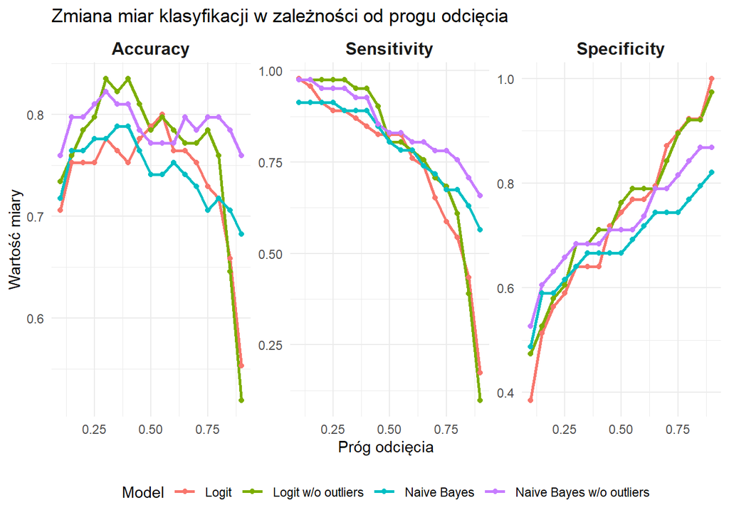

```r
evaluate_cutoff <- function(prog, prob, y_true) {
  pred <- factor(ifelse(prob >= prog, 1, 0), levels = c(0,1))
  y_true <- factor(y_true, levels = c(0,1))
  cm <- confusionMatrix(pred, y_true, positive = "1")
  return(data.frame(
    cutoff = prog,
    Accuracy = cm$overall["Accuracy"],
    Sensitivity = cm$byClass["Sensitivity"],
    Specificity = cm$byClass["Specificity"]
  ))
}

#progi odcięcia
cutoffs <- seq(0.1, 0.9, by = 0.05)

results_logit <- do.call(rbind, lapply(cutoffs, function(c) {
  evaluate_cutoff(c, pred_testowy, testowy$stroke)
}))

results_logit2 <- do.call(rbind, lapply(cutoffs, function(c) {
  evaluate_cutoff(c, pred_testowy2, testowy2$stroke)
}))

results_nb <- do.call(rbind, lapply(cutoffs, function(c) {
  evaluate_cutoff(c, pred_nb_test[, "1"], testowy$stroke)
}))

results_nb2 <- do.call(rbind, lapply(cutoffs, function(c) {
  evaluate_cutoff(c, pred_nb_test2[, "1"], testowy2$stroke)
}))


results_logit$model <- "Logit"
results_logit2$model <- "Logit w/o outliers"
results_nb$model <- "Naive Bayes"
results_nb2$model <- "Naive Bayes w/o outliers"

# Połączenie wszystkich wyników
results_all <- bind_rows(results_logit, results_logit2, results_nb, results_nb2)

# Przekształcenie do formatu long dla ggplot
results_long <- results_all %>%
  pivot_longer(cols = c("Accuracy", "Sensitivity", "Specificity"),
               names_to = "Metric",
               values_to = "Value")

ggplot(results_long, aes(x = cutoff, y = Value, color = model)) +
  geom_line(linewidth = 1) +
  geom_point() +
  facet_wrap(~ Metric, scales = "free_y") +
  labs(
    title = "Zmiana miar klasyfikacji w zależności od progu odcięcia",
    x = "Próg odcięcia",
    y = "Wartość miary",
    color = "Model"
  ) +
  theme_minimal() +
  theme(
    strip.text = element_text(size = 12, face = "bold"),
    legend.position = "bottom"
  )
```

## Krzywa ROC dla wszystkich modeli

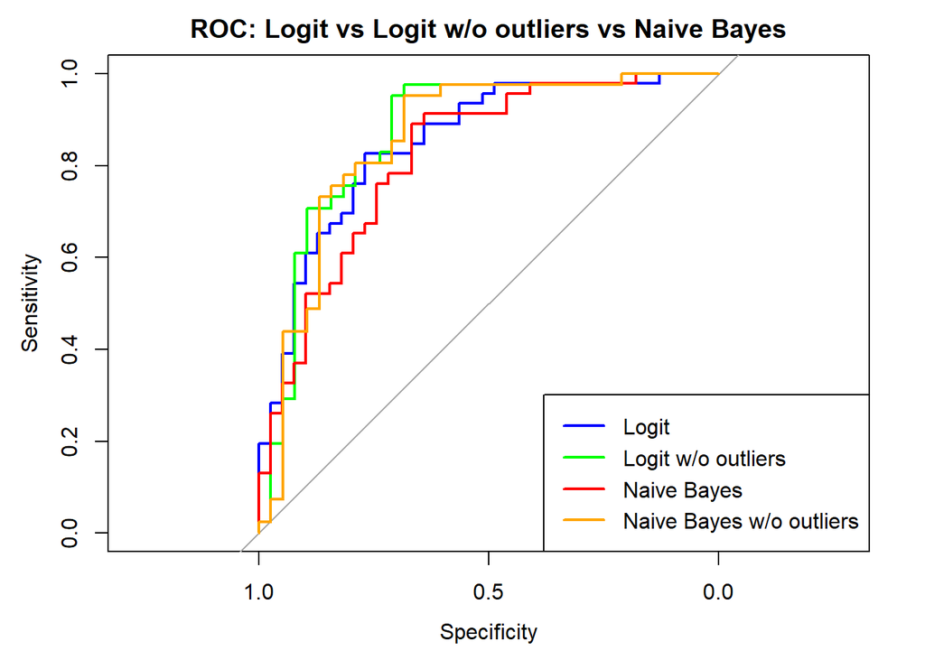

```r
plot(roc_logit, col="blue", main="ROC: Logit vs Logit w/o outliers vs Naive Bayes")
lines(roc_logit2, col="green")
lines(roc_nb, col="red")
lines(roc_nb2, col = "orange")
legend("bottomright", legend=c("Logit", "Logit w/o outliers", "Naive Bayes", "Naive Bayes w/o outliers"), col=c("blue", "green", "red", "orange"), lwd=2)
```

# Odpowiedzi na pytania z zadania 3

1)**Próg odcięcia** to wartość graniczna, przy której model uznaje obserwację za 1 (ma udar) lub 0 (nie ma udaru). Domyślnie jest 0.5 jednak można ustawić inną. Zmiana progru wpływa na czułość,dokładność, specyficzność.

2)**Krzywa ROC** (Receiver Operating Characteristic) ROC to wykres, który pokazuje zdolność modelu klasyfikacyjnego do rozróżniania dwóch klas (u nas udar vs. brak udaru) przy różnych progach odcięcia.

Działanie: -Model regresji logistycznej (lub Bayesa) daje prawdopodobieństwa wystąpienia zdarzenia (stroke = 1) dla każdej obserwacji. -Aby przypisać obserwację do klasy 1 lub 0, używamy progu odcięcia.

Tru Positive Rate (TPR)-czułość

$$\text{TPR} = \frac{TP}{TP + FN}$$
gdzie TP(true positive)=liczba prawdziwych trafień pozytywnych TP+FN(tru positive+ false negative)=czyli liczba wszystkich faktycznie pozytywnych
$$\text{FPR} = \frac{FP}{FP + TN}$$
gdzie: FP(false positive)=Liczba fałszywych trafien pozytywnych FP+TN(false positive+true negative)=Liczba wszytskich faktycznie negatywnych

Jeśli zmieniamy ten próg odcięcia od 0 do 1, zmienia się: -True Positive Rate (TPR) – czułość: proporcja poprawnie sklasyfikowanych przypadków pozytywnych, -False Positive Rate (FPR) – 1 – swoistość: proporcja błędnie sklasyfikowanych przypadków negatywnych.

ROC rysuje TPR na osi Y vs. FPR na osi X przy wszystkich możliwych progach.

Krzywa pokazuje, jak zmiana progu wpływa na kompromis między czułością a swoistością.

Idealny model= krzywa jak najbardziej w lewy górny róg Model losowy =krzywa wzdłuż przekątnej

W naszym modelu sprawdziliśmy następujące progi: 0.10, 0.15, 0.20, 0.25, 0.30, 0.35, 0.40, 0.45, 0.50, 0.55, 0.60, 0.65, 0.70, 0.75, 0.80, 0.85, 0.90

**Wartość AUC** (Area Under Curve)

AUC to pole pod krzywą ROC, czyli liczba między 0 a 1, która podsumowuje zdolność modelu do rozróżniania klas.

AUC Interpretacja: 0.5 = model losowy (brak zdolności klasyfikacji) 0.6–0.7 = słaba klasyfikacja 0.7–0.8 = przyzwoita 0.8–0.9 = dobra 0.9–1.0 = bardzo dobra/świetna

3)Krzywe są zaprezentowane powyżej